# Visualizacion - Comunicar con Graficos

para más información https://ggplot2.tidyverse.org/reference/

## Etiquetas

labs() es una de las funciones que podemos utilizar para agregar etiquetas

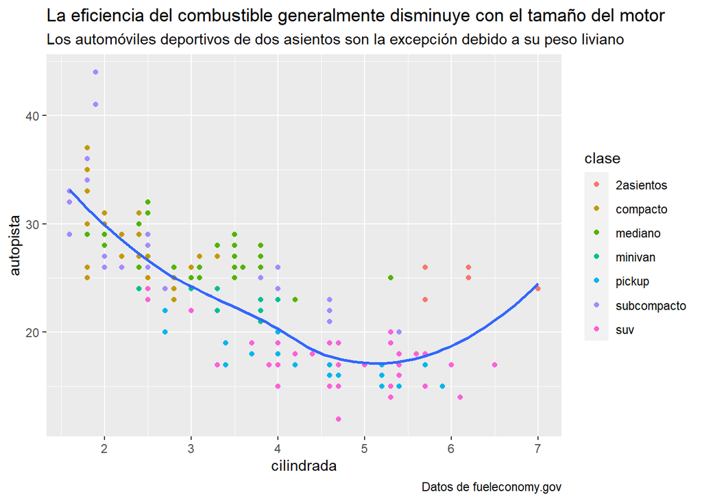

```r
ggplot(millas, aes(cilindrada, autopista)) +
  geom_point(aes(color = clase)) +
  geom_smooth(se = FALSE) +
  labs(
    title = "La eficiencia del combustible generalmente disminuye con el tamaño del motor",
    subtitle = "Los automóviles deportivos de dos asientos son la excepción debido a su peso liviano",
    caption = "Datos de fueleconomy.gov"
  )
```

También se puede usar labs() para cambiar nombre de ejes, y de los cuadros por ejemplo de color.

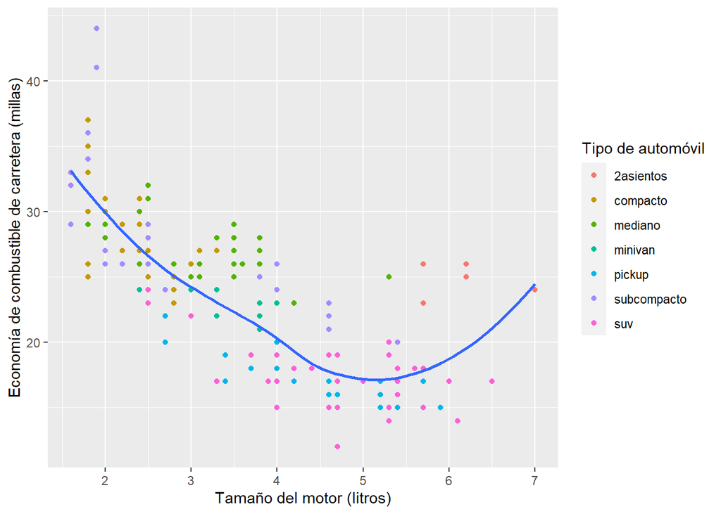

```r
ggplot(millas, aes(cilindrada, autopista)) +
  geom_point(aes(colour = clase)) +
  geom_smooth(se = FALSE) +
  labs(
    x = "Tamaño del motor (litros)",
    y = "Economía de combustible de carretera (millas)",
    colour = "Tipo de automóvil"
  )
```

En los ejes también se pueden escribir fórmulas con quote(): Más acerca de opciones disponibles en ?plotmath

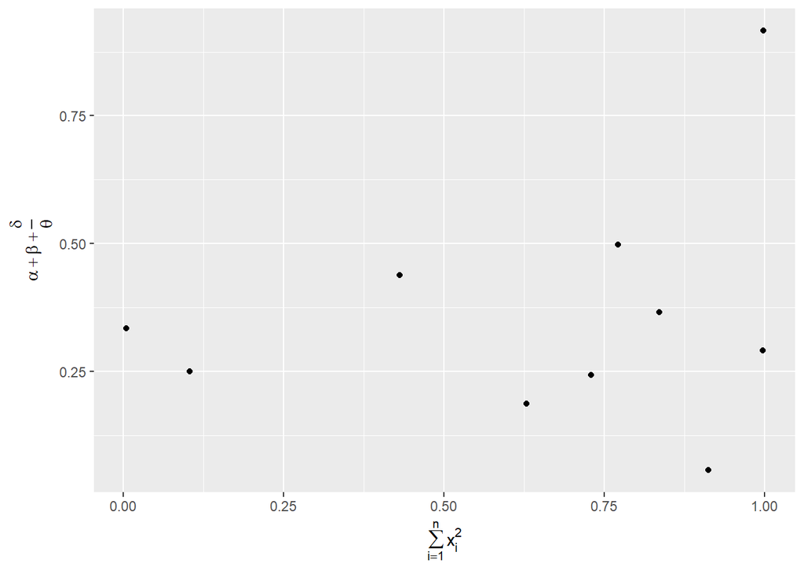

```r
df <- tibble(
  x = runif(10),
  y = runif(10)
)

ggplot(df, aes(x, y)) +
  geom_point() +
  labs(
    x = quote(sum(x[i]^2, i == 1, n)),
    y = quote(alpha + beta + frac(delta, theta))
  )
```

## Anotaciones

Para etiquetar partes principales del gráfico, grupos de observaciones u observaciones individuales. * geom_text(): es similar a geom_point() pero agrega label. Ojo que se pueden superponer… * geom_label(): arma un recuadro alrededor del texto. También se puede superponer (con opción nudge_y se mueve el label un poco por encima) * paquete ggrepel: ajusta automáticamente las etiquetas para que no se superpongan.

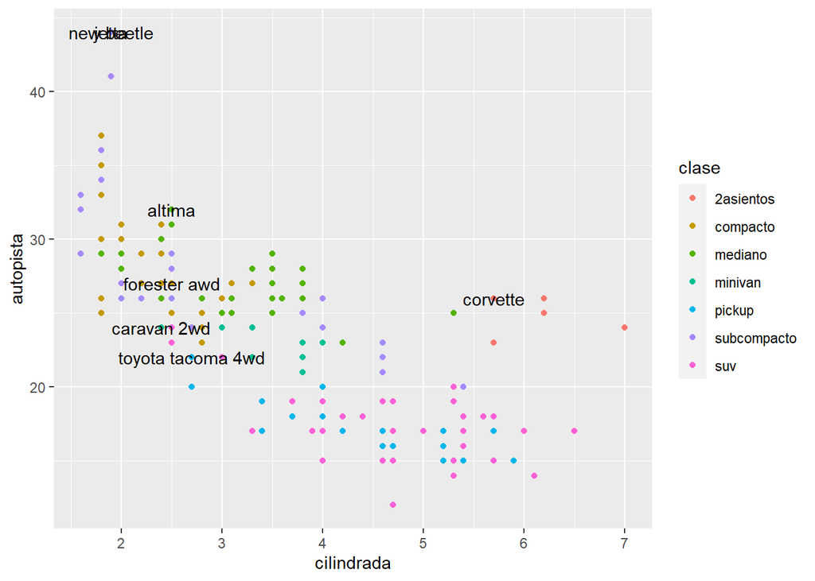

```r
mejor_de_su_clase <- millas %>%
  group_by(clase) %>%
  filter(row_number(desc(autopista)) == 1)

ggplot(millas, aes(cilindrada, autopista)) +    #geom_text
  geom_point(aes(colour = clase)) +
  geom_text(aes(label = modelo), data = mejor_de_su_clase)
```

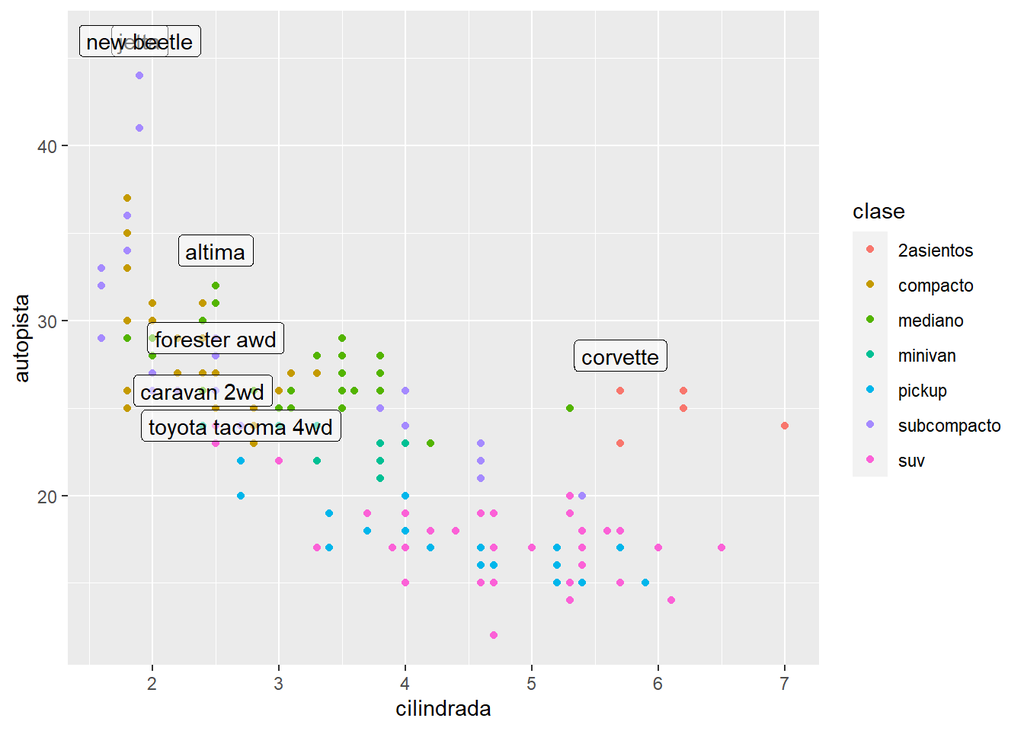

```r
ggplot(millas, aes(cilindrada, autopista)) +    #geom_label
  geom_point(aes(colour = clase)) +
  geom_label(aes(label = modelo), data = mejor_de_su_clase, nudge_y = 2, alpha = 0.5)
```

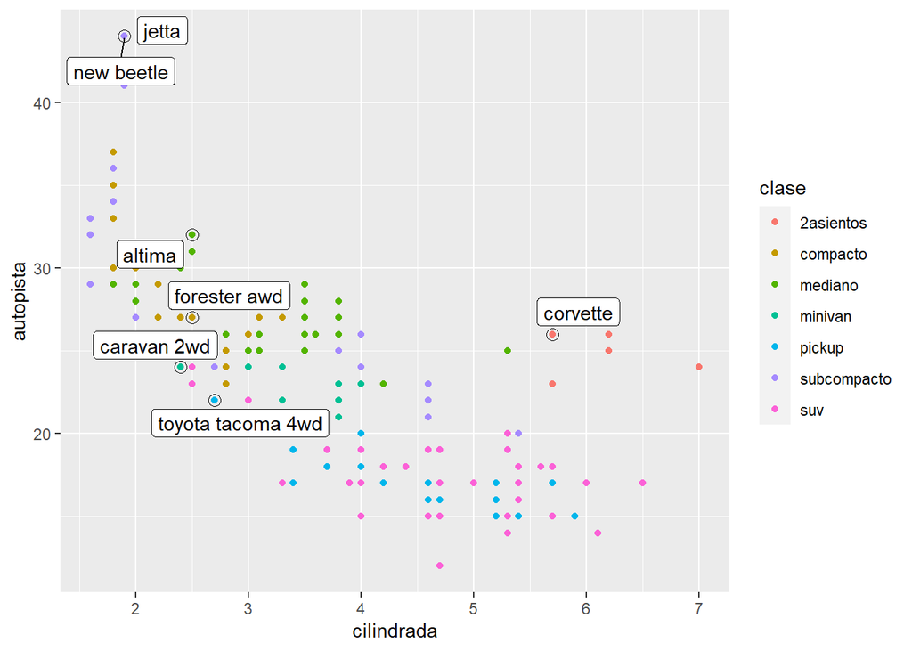

```r
ggplot(millas, aes(cilindrada, autopista)) +    #ggrepel::geom_label_repel
  geom_point(aes(colour = clase)) +
  geom_point(size = 3, shape = 1, data = mejor_de_su_clase) +
  ggrepel::geom_label_repel(aes(label = modelo), data = mejor_de_su_clase)
```

```r
# técnica muy práctica utilizada aquí: agregar  segunda capa de puntos grandes y huecos para resaltar los puntos etiquetados.
```

También se puede utilizar esta técnica para eliminar la leyenda del cuadro, y que los textos esten en el mismo gráfico.

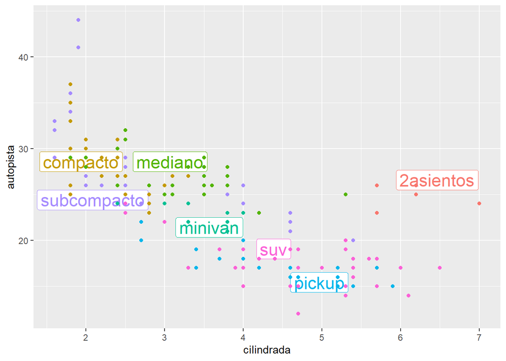

```r
clase_promedio <- millas %>%
  group_by(clase) %>%
  summarise(
    cilindrada = median(cilindrada),
    autopista = median(autopista)
  )

ggplot(millas, aes(cilindrada, autopista, colour = clase)) +
  ggrepel::geom_label_repel(aes(label = clase),
    data = clase_promedio,
    size = 6,
    label.size = 0,
    segment.color = NA
  ) +
  geom_point() +
  theme(legend.position = "none")
```

También se puede querer agregar una única leyenda al gráfico. pero igualmente hay que generar un set de datos.  
**Notar el /n en el texto para que se imprima en 2 lineas**  
**Otra posibilidad es usar stringr::str_wrap() para agregar saltos de línea automáticamente, dado el número de caracteres que se desea por línea.**

```r
"El aumento del tamaño del motor está relacionado con la disminución en el gasto de combustible." %>%
  stringr::str_wrap(width = 40) %>%
  writeLines()
```

```
## El aumento del tamaño del motor está
## relacionado con la disminución en el
## gasto de combustible.
```

```
#> El aumento del tamaño del motor está
#> relacionado con la disminución en el
#> gasto de combustible.
```

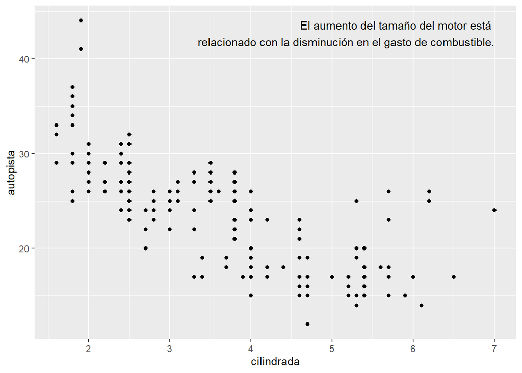

```r
etiqueta <- millas %>%       # derecha arriba según datos máximos
  summarise(
    cilindrada = max(cilindrada),
    autopista = max(autopista),
    etiqueta = "El aumento del tamaño del motor está \nrelacionado con la disminución en el gasto de combustible."
  )

ggplot(millas, aes(cilindrada, autopista)) +
  geom_point() +
  geom_text(aes(label = etiqueta), data = etiqueta, vjust = "top", hjust = "right")
```

Si deseas colocar el texto exactamente en los bordes del gráfico puedes usar +Inf y -Inf. Como ya no estamos calculando las posiciones de millas, podemos usar tibble() para crear el conjunto de datos:

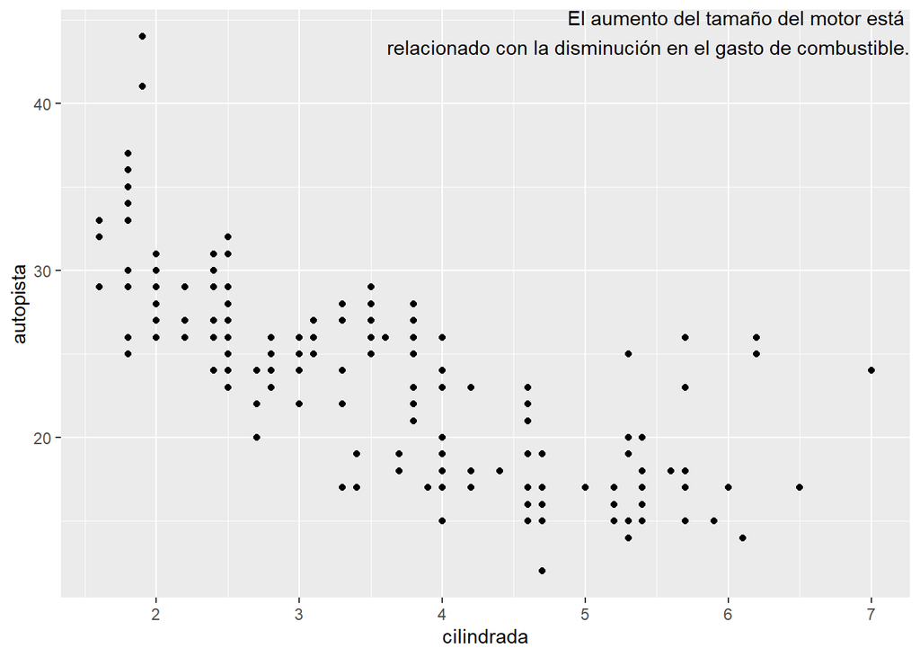

```r
# etiqueta <- millas %>%
#   summarise(
#     cilindrada = Inf,
#     autopista = Inf,
#     etiqueta = "El aumento del tamaño del motor está \nrelacionado con la disminución en el gasto de combustible."
#  )
etiqueta <- tribble(
  ~cilindrada, ~ autopista, ~ etiqueta,
    Inf, Inf, "El aumento del tamaño del motor está \nrelacionado con la disminución en el gasto de combustible."
)

ggplot(millas, aes(cilindrada, autopista)) +
  geom_point() +
  geom_text(aes(label = etiqueta), data = etiqueta, vjust = "top", hjust = "right")
```

## Posiciones vjust_hjust para agregar etiquetas

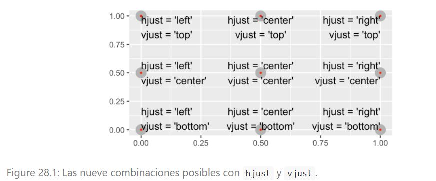

## Para recordar.. otros geoms para ayudar y agregar texto:

- geom_hline y geom_vline para agregar lineas de referencia. A menudo las hago gruesas (size = 2) y blancas (color = white), y las dibujo debajo de la primera capa de datos. Eso las hace fáciles de ver, sin distraer la atención de los datos.
- geom_rect() para dibujar un rectángulo alrededor de los puntos de interés. Los límites del rectángulo están definidos por las estéticas xmin,xmax, ymin,ymax
- geom_segment() con el argumento arrow para destacar un punto en particular con una flecha. Usa la estética x e y para definir la ubicación inicial, y xend y yend para definir la ubicación final.

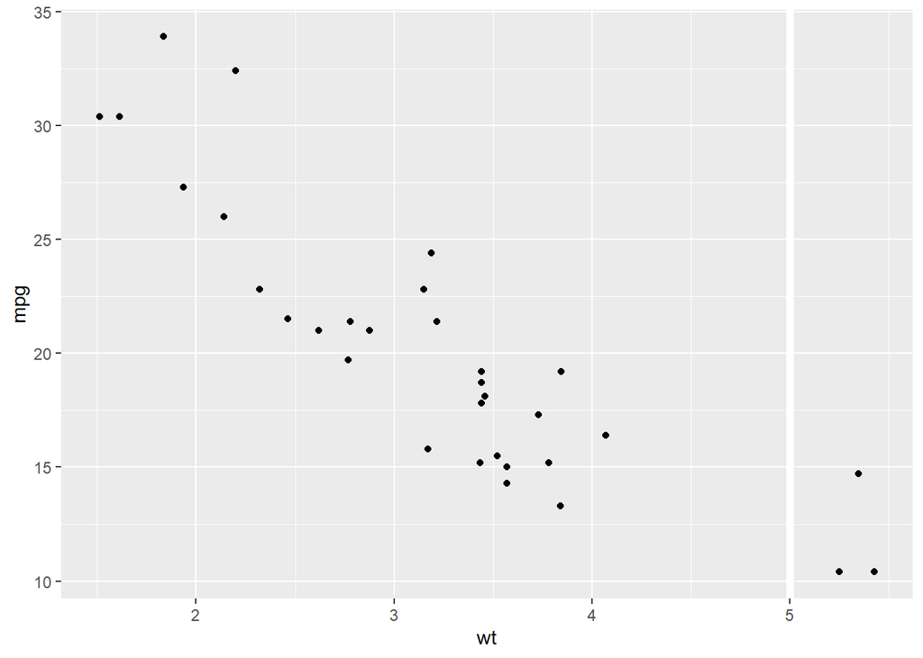

```r
p <- ggplot(mtcars, aes(wt, mpg)) + geom_point()
p + geom_vline(xintercept = 5, size = 2, color = "white") # muestra la linea en blanco y con grosor
```

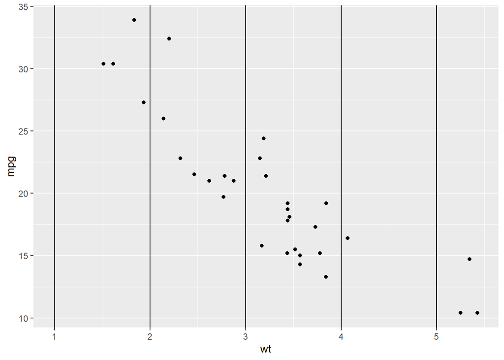

```r
p + geom_vline(xintercept = 1:5)
```

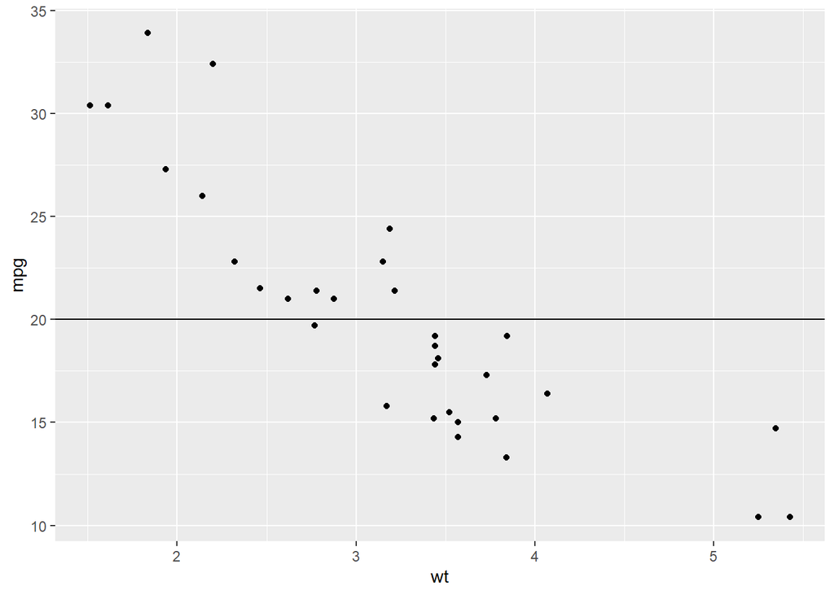

```r
p + geom_hline(yintercept = 20)
```